# lab1

Theory Questions - Experiment 1

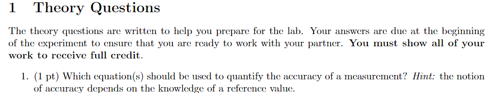

Absolute errror or relative relative equations

The uncertainty propagation equation should be used to quantify overall precision

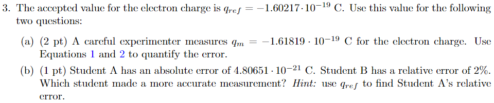

```python
print(-1.60217 - (-1.61819))

abs(-1.60217 - (-1.61819))/abs(-1.60217)
```

```
0.016019999999999923
```

```
0.009998938939063846
```

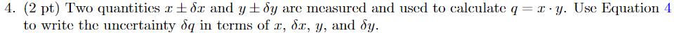

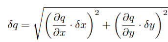

$ab^x$ vs $ax^b$. Growth-wise, exponential functions grow/decay faster than polynomial

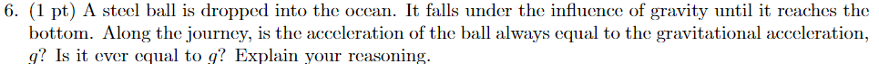

The acceleration varies since there is a drag force and a bouyant force as it moves through the water

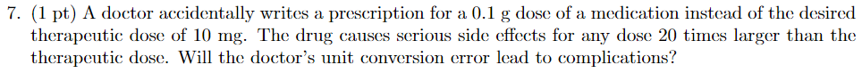

0.1g = 100mg, so it should be fine

3.1

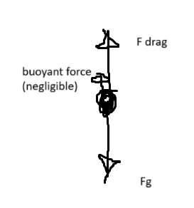

2. Acceleration is zero
3. Terminal velocity occurs when $F_D = F_g$.

$$ -mg = -\frac{1}{2}C_D \rho A_{cs} v^2\hat v \\ v = \sqrt{\frac{2mg}{C_{D} \rho A_{cs}}} $$ Thanks to $\hat v$, we know the solution must be negative.

Using the constants provided and $C_D = 0.47$ this is

$$ v = -\sqrt{\frac{2*981}{0.47*1.25*28}m} = -\sqrt{119.27 m} = -10.92\sqrt{m}\ \text{m/s} $$

4. $y = (-10.92)x^{0.5}$

Note: a later section asks us to find $C_D$ using curve.fit instead of assuming it. Maybe the answer we want here is $|v_T| = Am^{B}$?

5. $A = -\sqrt{\frac{2g}{C_{D} \rho A_{cs}}} $ and $B=0.5$

3.2

$$ C_D \rho A_{cs} = \frac{2g}{A^2} \\ C_D = \frac{2g}{A^2 \rho A_{cs}} = \frac{2*981}{11.67^2 * 1.25 * 28} = 0.412 $$

Which is pretty close to my earlier assumption of $0.47$

4. Uncertainty comes from $A$ and $A_{cs}$, all others are $\delta n=0$

$$ \frac{\partial C_D}{\partial A_{cs}}= \frac{2g}{A^2 \rho} \left(-\frac{1}{A_{cs}^2} \right)\\ \frac{\partial C_D}{\partial A}= \frac{2g}{A_{cs} \rho} \left(-\frac{2}{A^3} \right)\\ $$